# Spillane and Himes: Partners in Crime

07 March, 2021

#### by Geetansh Agarwal, Soham Bagchi and Wangchen Tsomu

## Introduction

This project analyses the genre of American detective fiction by closely comparing the works of two authors – Chester Himes and Mickey Spillane. The two authors wrote in the 1950s when the Cold War was at its peak and the United States witnessed the growth of the Civil Rights Movement, two factors that shaped America’s socio-political culture in these decades following World War II. They had a profound effect on American literature as well because they moulded the consumption patterns of American readers, especially in mass-entertainment genres like detective fiction. Himes’ and Spillane’s books stood out from other canonical works of American detective fiction because their focus – with respect to their depiction of American culture and society in the 1950s – was different, new and influenced by the two factors mentioned above. Our project compares Himes’ and Spillane’s novels and analyses the differences between their socio-political aims, which could be studied through their distinct writing styles, use of language and character depictions.

## Research Hypothesis

Analysing the socio-political aims of Mickey Spillane’s and Chester Himes’ detective fiction reveals that Spillane follows a consumerist approach by majorly portraying patriotic American heroes in his plotlines whereas Himes deals with the complexities of the African-American community and the social, political, economic and racial injustices they face in the United States.

## Corpus Description

We created two corpora for our research - one for each author. We figured we needed two corpora because we intended to compare and contrast their novels, and it would help us make the task easier. Within each corpora, we included the books written by the authors from early 1950s to the late 1960s. This period of thirty years had transformed the US culturally and politically, which must have resulted in the authors moulding and altering their writing style, plot lines and so on. We believe that by adding a temporal category in our analysis, we would also be able to analyse not only the differences between Himes’ and Spillane’s works but also the change in their own writing over time.

```r
# Importing Individual Author Corpora from CSV, then concatenating
himes_corpus <- read.csv("raw_corpus_himes.csv",
                            stringsAsFactors = FALSE)
spillane_corpus <- read.csv("raw_corpus_spillane.csv",
                            stringsAsFactors = FALSE)
corpus <- bind_rows(himes_corpus, spillane_corpus)
```

## Summary

The tables below reveal the number of unique entities per title, by both the authors. The table on the right reveals the average number of unique locations and persons for each author. Here we can see that Chester Himes has been more generous when creating more characters and habitating more locations.

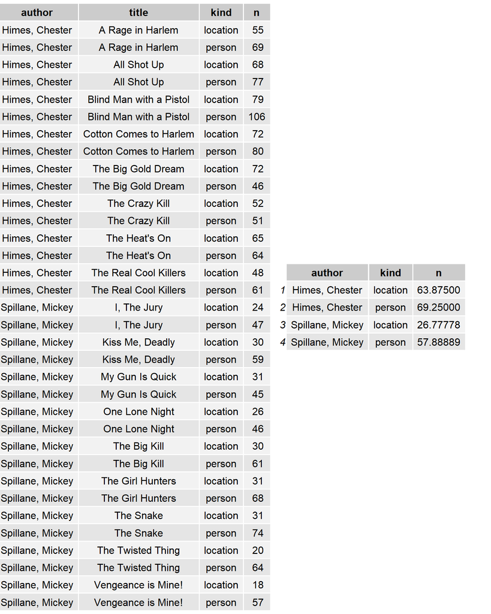

```r
# Import Cleaned-Up Entities
clean_entities_test <- read.csv("bookwise_entities_final_clean.csv",
                                 stringsAsFactors = FALSE)

# Group by Author and Title and Sum Unique Entities Per Title
unique_entity_count <- clean_entities_test %>%
  group_by(author, title) %>%
  count(kind)

# Calculate Average Unique Entities Per Title (for each Author)
average_unique_entity_count <- subset(unique_entity_count,
                                      select = -c(title)) %>%
  group_by(author, kind) %>%
  mutate(n = mean(n)) %>%
  distinct()

unique_entity_count_table <- tableGrob(unique_entity_count)
average_unique_entity_count_table <- tableGrob(average_unique_entity_count)

grid.arrange(unique_entity_count_table,
             average_unique_entity_count_table,
             nrow = 1, ncol = 2)
```

### Sentiment Analysis (Story Progress)

```r
tidy_by_author <- function(authorName){
  require(dplyr)
  tidy_books_author <- corpus %>%
    filter(author == authorName) %>%
    group_by(title) %>%
    mutate(linenumber = row_number(),
           chapter = cumsum(str_detect(text, regex("^chapter [\\divxlc]",
                                                   ignore_case = TRUE)))) %>%
    ungroup() %>%
    unnest_tokens(word, text)
  return(tidy_books_author)
}

author_sentiment_analysis <- function(authorFrame, sentFetch, lineChap){
  require(dplyr)
  if(lineChap == 0){
    authorSentiment <- authorFrame %>%
      inner_join(get_sentiments(sentFetch)) %>%
      count(title, index = linenumber %/% 40, sentiment) %>%
      spread(sentiment, n, fill = 0) %>%
      mutate(sentiment = positive - negative)
    return(authorSentiment)
  } else {
    authorSentiment <- authorFrame %>%
      inner_join(get_sentiments(sentFetch)) %>%
      count(title, index = chapter, sentiment) %>%
      spread(sentiment, n, fill = 0) %>%
      mutate(sentiment = positive - negative)
    return(authorSentiment)
  }
}

himes_tidy <- tidy_by_author("Himes, Chester")
spillane_tidy <- tidy_by_author("Spillane, Mickey")

himes_sentiment <- author_sentiment_analysis(himes_tidy, "bing", 0)
spillane_sentiment <- author_sentiment_analysis(spillane_tidy, "bing", 0)
```

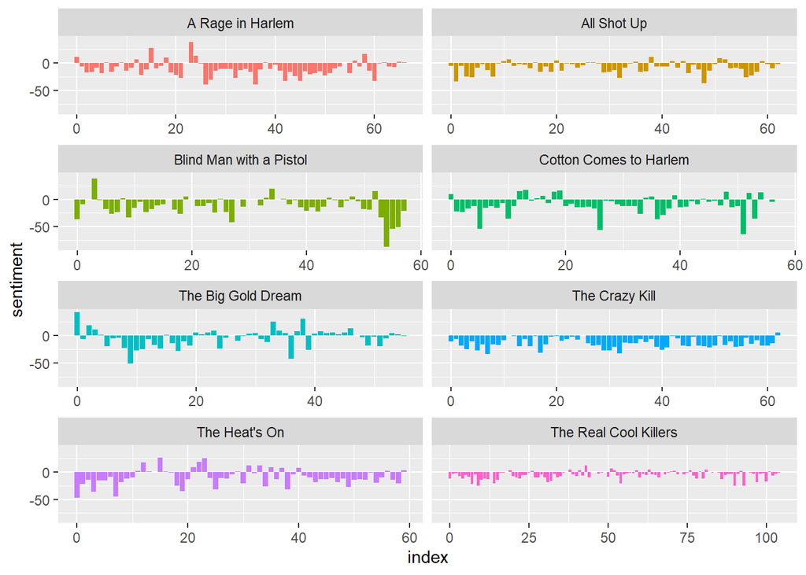

```r
ggplot(himes_sentiment, aes(index, sentiment, fill = title)) +
      geom_col(show.legend = FALSE) +
      facet_wrap(~title, ncol = 2, scales = "free_x")
```

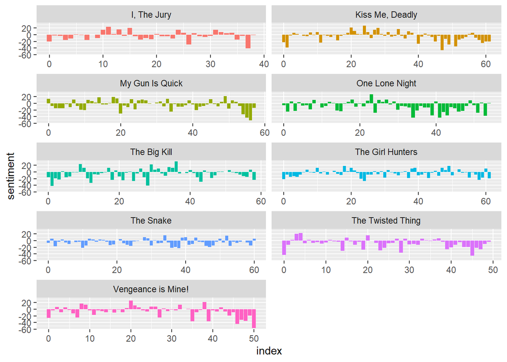

```r
ggplot(spillane_sentiment, aes(index, sentiment, fill = title)) +
      geom_col(show.legend = FALSE) +
      facet_wrap(~title, ncol = 2, scales = "free_x")
```

### Sentiment Analysis (Characters, Locations and Political Keywords)

```r
clean_entities <- read.csv("the_cleanest_entities_ever.csv",
                            stringsAsFactors = FALSE)

entities_unnest <- clean_entities %>%
                   unnest_tokens(word, words)

entities_sentiment <- entities_unnest %>%
                      group_by(author, title) %>%
                      inner_join(get_sentiments("nrc")) %>%
                      count(sentence_nr, sentiment) %>%
                      spread(sentiment, n, fill = 0) %>%
                      mutate(sentiment = positive - negative)

entities_matches_sentiment <- entities_unnest %>%
                              inner_join(entities_sentiment) %>%
                              distinct_at(vars(-word))

ner_total_sentiment <- entities_matches_sentiment %>%
                       group_by(author, title, entity, kind) %>%
                       summarise(total = mean(sentiment))
```

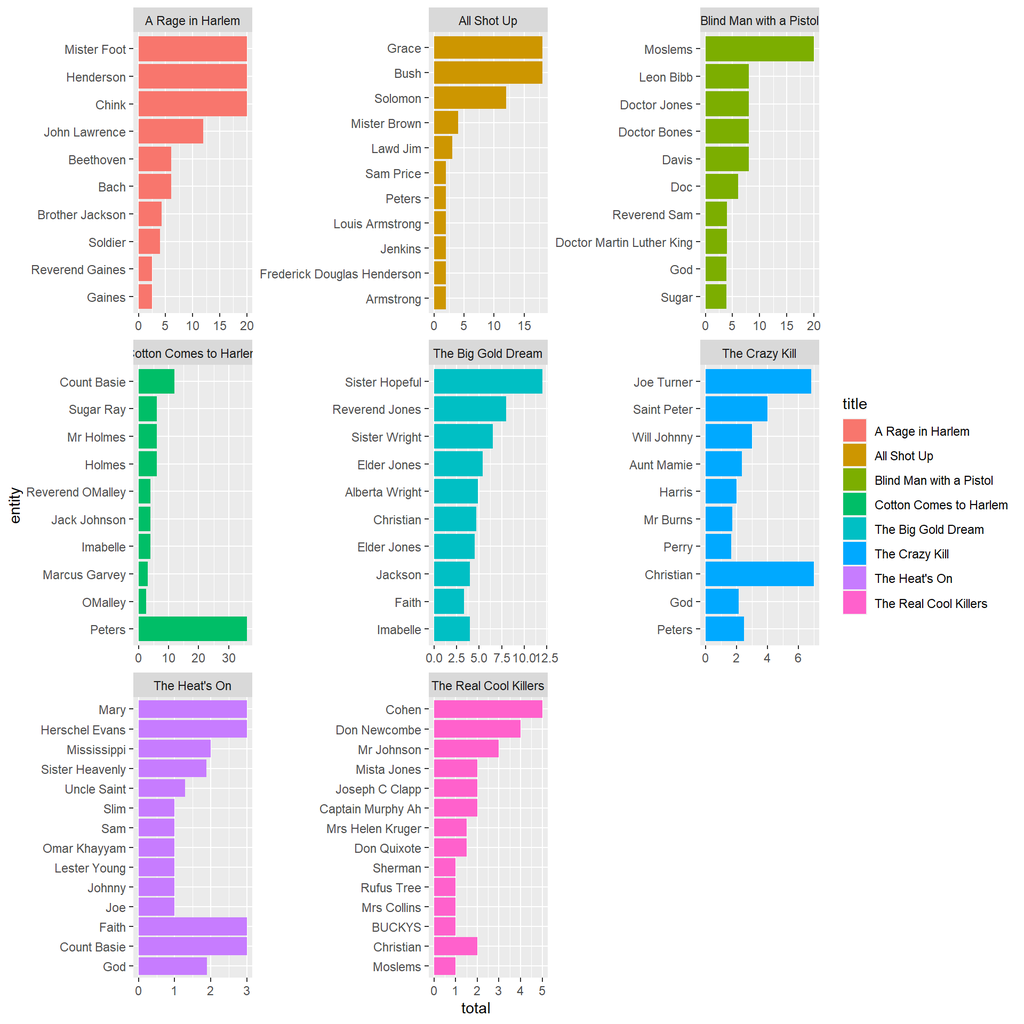

```r
ner_total_sentiment %>%
  group_by(author, title) %>%
  filter(kind == "person", author == "Himes, Chester") %>%
  top_n(10) %>%
  mutate(entity = reorder(entity, total)) %>%
  ggplot(aes(entity, y = total, fill = title)) +
  geom_col() +
  facet_wrap(~title, scales = "free") +
  coord_flip()
```

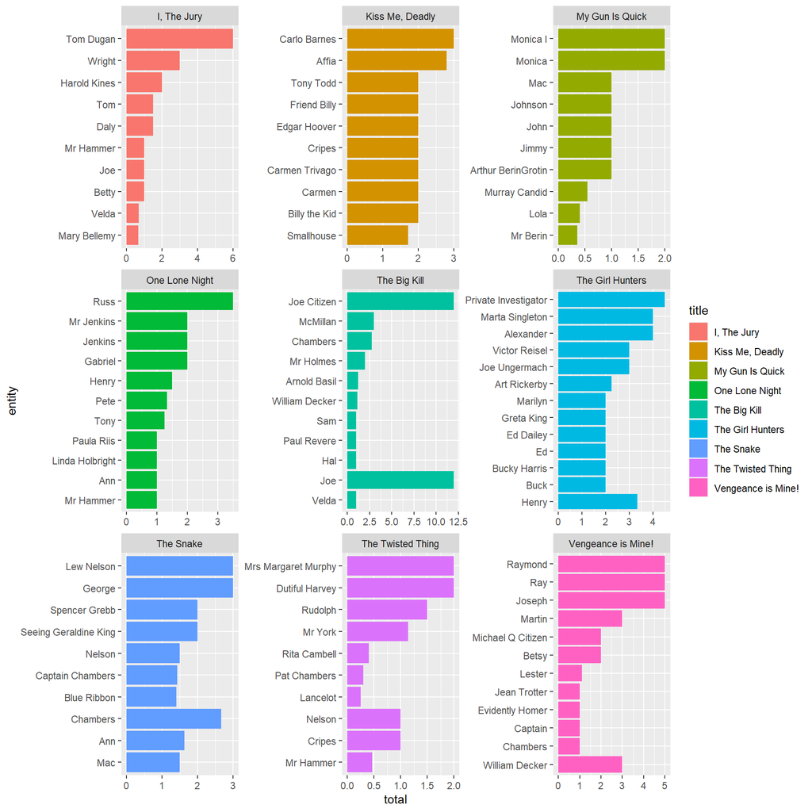

```r
ner_total_sentiment %>%
  group_by(author, title) %>%
  filter(kind == "person", author == "Spillane, Mickey") %>%
  top_n(10) %>%
  mutate(entity = reorder(entity, total)) %>%
  ggplot(aes(entity, y = total, fill = title)) +
  geom_col() +
  facet_wrap(~title, scales = "free") +
  coord_flip()
```

**CHARACTERS**

**Ed Johnson**

```r
radar_facet <- entities_matches_sentiment %>%
  select(-positive,-negative,-sentiment) %>% #drop out the unnecessary columns
  filter(kind == "person") %>%
  filter(entity == "Ed Johnson") %>%
  #filter(author == "Himes, Chester") %>%
  group_by(title, entity, kind) %>%
  summarise(across(anger:trust, sum)) %>%
  mutate(total = rowSums(across(where(is.numeric))))  %>%
  arrange(desc(total)) %>%
  head(10)  %>% #Change number to include more or fewer entities
  mutate(across(anger:trust, .fns = ~ round((. / total) * 100))) %>%
  select(-total)

ggRadar(
  data = radar_facet,
  mapping = aes(color = title, facet = entity),
  rescale = FALSE,
  interactive = TRUE,
  use.label = TRUE,
  size = 1,
  legend.position = "right"
)
```

[interactive chart not shown]

**Grave Digger Jones**

```r
radar_facet <- entities_matches_sentiment %>%
  select(-positive,-negative,-sentiment) %>% #drop out the unnecessary columns
  filter(kind == "person") %>%
  filter(entity == "Grave Digger Jones") %>%
  #filter(author == "Himes, Chester") %>%
  group_by(title, entity, kind) %>%
  summarise(across(anger:trust, sum)) %>%
  mutate(total = rowSums(across(where(is.numeric))))  %>%
  arrange(desc(total)) %>%
  head(10)  %>% #Change number to include more or fewer entities
  mutate(across(anger:trust, .fns = ~ round((. / total) * 100))) %>%
  select(-total)

ggRadar(
  data = radar_facet,
  mapping = aes(color = title, facet = entity),
  rescale = FALSE,
  interactive = TRUE,
  use.label = TRUE,
  size = 1,
  legend.position = "right"
)
```

[interactive chart not shown]

**Mike Hammer**

```r
radar_facet <- entities_matches_sentiment %>%
  select(-positive,-negative,-sentiment) %>% #drop out the unnecessary columns
  filter(kind == "person") %>%
  filter(entity == "Mike Hammer") %>%
  #filter(author == "Himes, Chester") %>%
  group_by(title, entity, kind) %>%
  summarise(across(anger:trust, sum)) %>%
  mutate(total = rowSums(across(where(is.numeric))))  %>%
  arrange(desc(total)) %>%
  head(10)  %>% #Change number to include more or fewer entities
  mutate(across(anger:trust, .fns = ~ round((. / total) * 100))) %>%
  select(-total)

ggRadar(
  data = radar_facet,
  mapping = aes(color = title, facet = entity),
  rescale = FALSE,
  interactive = TRUE,
  use.label = TRUE,
  size = 1,
  legend.position = "right"
)
```

[interactive chart not shown]

#### Politically Charged Terms

*We will also check our corpus for politically charged entities, gauging the sentiments of those as well. For this, we prepared a list of different entities we thought would be suitable for the time and space that these stories are based in.*

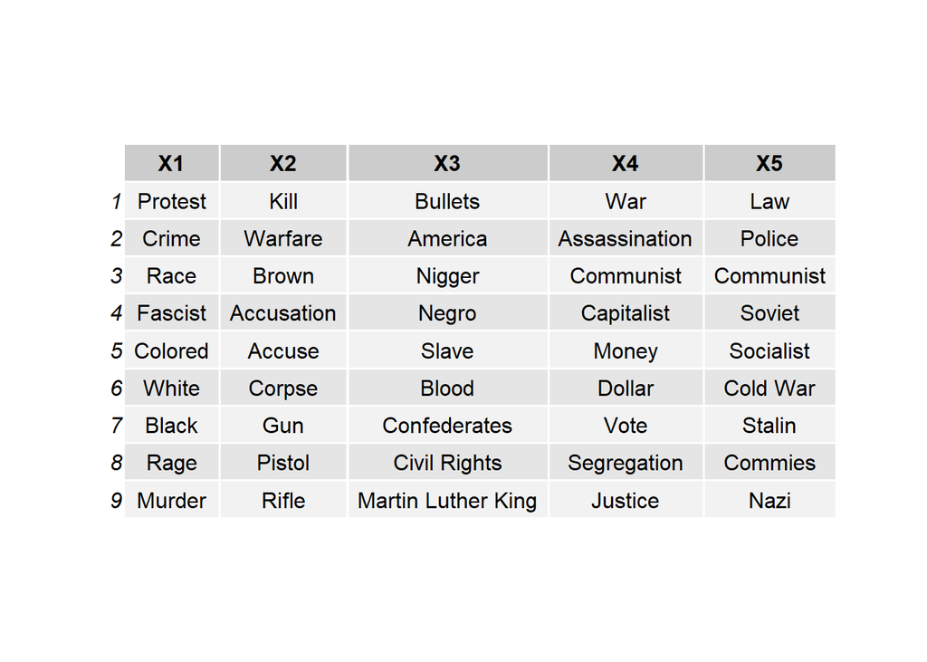

```r
clean_entities_neo <- read.csv("neo_entities_clean.csv",
                               stringsAsFactors = FALSE)

entities_unnest_neo <- clean_entities_neo %>%
                   unnest_tokens(word, words)

entities_sentiment_neo <- entities_unnest_neo %>%
                      group_by(author, title) %>%
                      inner_join(get_sentiments("nrc")) %>%
                      count(sentence_nr, sentiment) %>%
                      spread(sentiment, n, fill = 0) %>%
                      mutate(sentiment = positive - negative)

entities_matches_sentiment_neo <- entities_unnest_neo %>%
                              inner_join(entities_sentiment_neo) %>%
                              distinct_at(vars(-word))

ner_total_sentiment_neo <- entities_matches_sentiment_neo %>%
                       group_by(author, title, entity, kind) %>%
                       summarise(total = mean(sentiment))
```

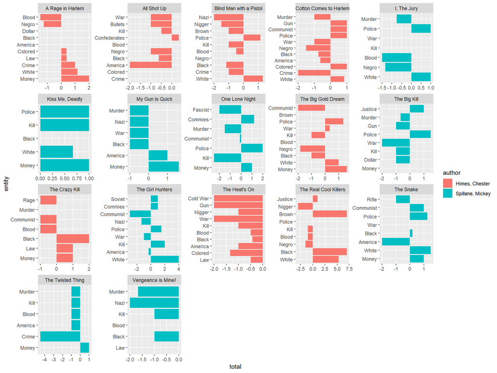

```r
ner_total_sentiment_neo %>%
  group_by(title) %>%
  filter(kind == "neo") %>%
  top_n(-10) %>%
  mutate(entity = reorder(entity, desc(total))) %>%
  ggplot(aes(entity, y = total, fill = author)) +
  geom_col() +
  facet_wrap(~title, scales = "free") +
  coord_flip()
```